# Assignment 1

Glenn Berkwitt

December 20, 2015

Load required libraries

```r
library(knitr)
opts_chunk$set(echo = TRUE)
library(dplyr)
library(lubridate)
```

```r
library(ggplot2)
```

*1. Loading and preprocessing the data*

Read in the data

```r
data <- read.csv("activity.csv", header = TRUE, sep = ',', colClasses = c("numeric", "character",
                                                           "integer"))
```

Format date data

```r
data$date <- as.Date(data$date)
```

Take a look at the formatted data

```r
str(data)
```

```
## 'data.frame':    17568 obs. of  3 variables:
##  $ steps   : num  NA NA NA NA NA NA NA NA NA NA ...
##  $ date    : Date, format: "2012-10-01" "2012-10-01" ...
##  $ interval: int  0 5 10 15 20 25 30 35 40 45 ...
```

```r
head(data)
```

```
##   steps       date interval
## 1    NA 2012-10-01        0
## 2    NA 2012-10-01        5
## 3    NA 2012-10-01       10
## 4    NA 2012-10-01       15
## 5    NA 2012-10-01       20
## 6    NA 2012-10-01       25
```

*2. What is mean total number of steps taken per day?*

Aggregate the data by date, adding the total steps per day

```r
stepsperday <- aggregate(steps~date, data, sum)
```

Aggregate the sum of steps per day

```r
sumstepsperday <- aggregate(data$steps ~ data$date, FUN=sum)
colnames(sumstepsperday)<- c("Date", "Steps")
```

Take a look at it to make sure things have been aggregated correctly

```r
head(sumstepsperday)
```

```
##         Date Steps
## 1 2012-10-02   126
## 2 2012-10-03 11352
## 3 2012-10-04 12116
## 4 2012-10-05 13294
## 5 2012-10-06 15420
## 6 2012-10-07 11015
```

Make a histogram of the total steps per day

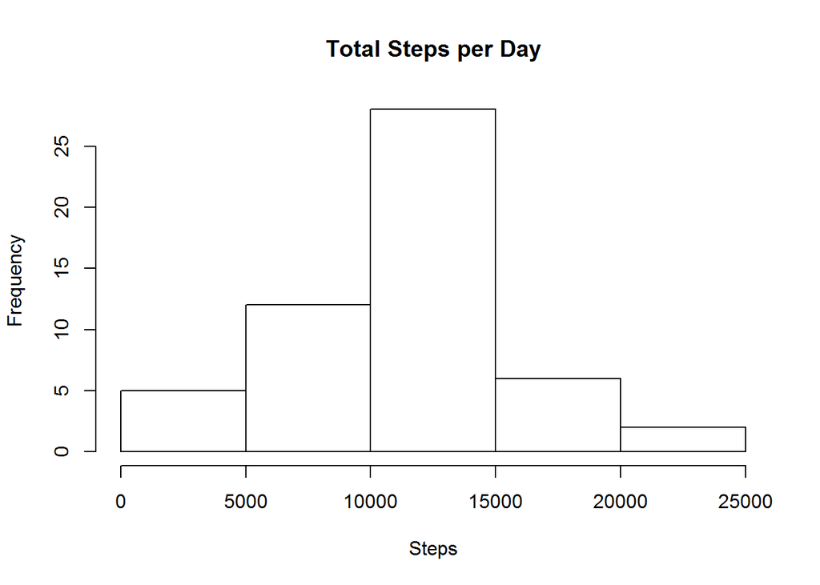

```r
hist(sumstepsperday$Steps, breaks=5, xlab="Steps", main = "Total Steps per Day")
```

Calculate mean

```r
as.integer(mean(sumstepsperday$Steps))
```

```
## [1] 10766
```

Mean is 10766 steps per day

Calculate median

```r
as.integer(median(sumstepsperday$Steps))
```

```
## [1] 10765
```

Median is 10765 steps per day

*3. What is the average daily activity pattern?*

Aggregate the number of steps per 5-minute interval, take the mean of each interval

```r
stepsperinterval<-aggregate(steps~interval,data,mean)
```

*3.1. Make a time-series plot of the 5-minute intervals and the mean of steps taken per interval*

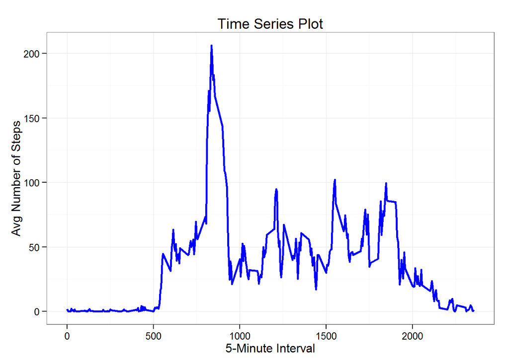

```r
timeseriesplot<-ggplot(stepsperinterval, aes(stepsperinterval$interval, stepsperinterval$steps))+geom_line(color="blue",size=1)+theme_bw()
timeseriesplot<-timeseriesplot+xlab("5-Minute Interval")+ylab("Avg Number of Steps")+ggtitle("Time Series Plot")
timeseriesplot
```

*3.2.Which 5-minute interval, on average, across all days in the dataset, contains the maximum number of steps?*

```r
stepsperinterval[which.max(stepsperinterval$steps),]
```

```
##     interval    steps
## 104      835 206.1698
```

Shows that interval with highest number of steps is 835 is with 206.17 steps

*4. Impute missing values*

*4.1. Summarize all the missing values to show number of missing values*

```r
sum(is.na(data$steps))
```

```
## [1] 2304
```

Shows that there are 2304 lines with missing data

*4.2. Devise a strategy for filling in all of the missing values in the dataset.*

Create a new dataset as the original and use a for loop for filling in the missing values with the average number of steps per 5-minute interval:

*4.3. Create a new data frame, a copy of the original data set with NAs included.*

```r
data2<-data
```

Convert dates and steps as done with original data set

```r
data2$date<-as.Date(data2$date)
data2$steps<-as.numeric(data2$steps)
```

Create a for-loop that writes over any NA values with the mean of that 5-minute interval

```r
for (i in 1:nrow(data2)) {
        if (is.na(data2$steps[i])){
                data2$steps[i] <- stepsperinterval[which(data2$interval[i] == stepsperinterval$interval), ]$steps
                        }
                }
```

Aggregate the new filled-in data set by date, adding the total steps per day

```r
stepsperday2<-aggregate(steps~date,data2,sum)
```

*4.4. Make a new histogram using the filled-in data set*

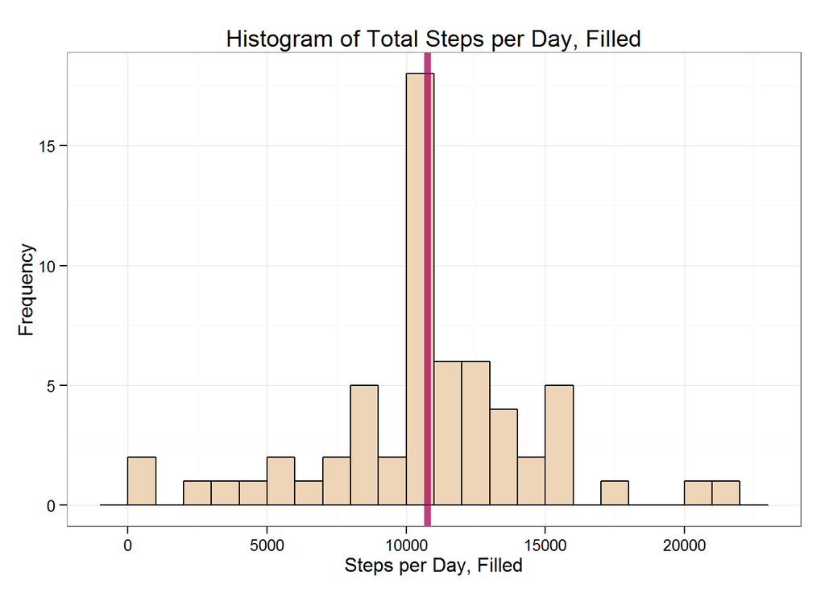

```r
Filleddata<-ggplot(stepsperday2,aes(x=stepsperday2$steps))+theme_bw()+geom_histogram(fill="bisque2",color="black",binwidth=1000)
Filleddata<-Filleddata+geom_vline(xintercept=mean(stepsperday2$steps,na.rm=TRUE),size=2,color="blue",alpha=.5)+
geom_vline(xintercept=median(stepsperday2$steps,na.rm=TRUE),size=2,color="red",alpha=.5)
Filleddata<-Filleddata+xlab("Steps per Day, Filled")+ylab("Frequency")+ggtitle("Histogram of Total Steps per Day, Filled")
Filleddata
```

Obtain the new mean and median from our filled-in data set

```r
mean(stepsperday2$steps)
```

```
## [1] 10766.19
```

```r
median(stepsperday2$steps)
```

```
## [1] 10766.19
```

Shows there is no appreciable difference between that data with NAs and the data in which the NAs have been filled in.

*5. Are there differences in activity patterns between weekdays and weekends?*

Copy the filled in data frame and work on it while protecting the original.

```r
data2daytypes <- data2
```

Add new column to our data set listing the specific day of the week

```r
data2daytypes$day<-weekdays(data2daytypes$date)
```

Runs a for-loop that looks for days that are weekends vs. weekdays

```r
wkdvswend <- function(x){
        if(x %in% c("Saturday", "Sunday")) {
                return("Weekend")
  }
                else(return("Weekday"))
  }
```

Create a new “weekday” column that uses the for-loop to populate whether the specific day is during the weekend vs. weekday

```r
data2daytypes$weekday<-as.factor(sapply(data2daytypes$day,wkdvswend))
```

Aggregate the means of the steps by weekday and by 5-minute interval

```r
aggdaytype<-aggregate(steps~interval+weekday,data2daytypes, mean)
```

*5.2. Make a panel plot to show the difference in the means of steps between weekdays vs weekends*

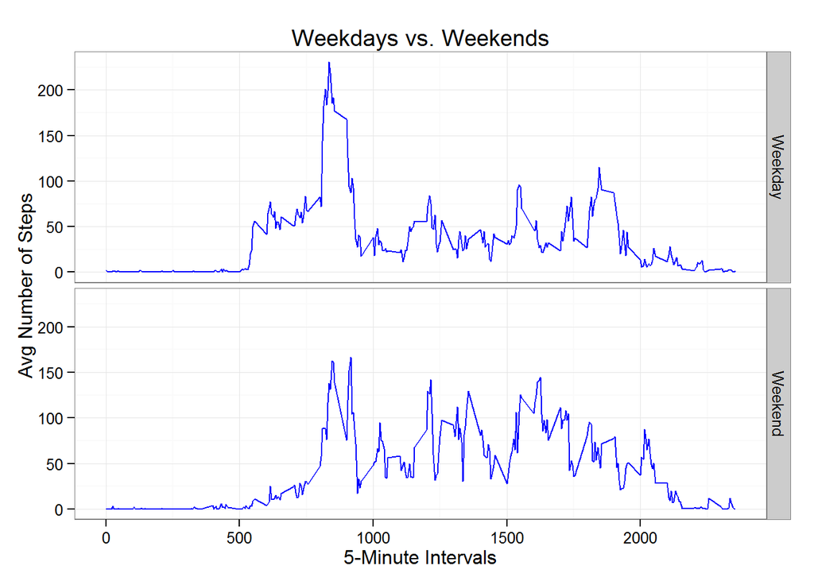

```r
wkdvswkendplot<-ggplot(aggdaytype,aes(x=interval, y=steps))+geom_line(color="blue")+facet_grid(weekday~.)+theme_bw()
wkdvswkendplot<-wkdvswkendplot+xlab("5-Minute Intervals")+ylab("Avg Number of Steps")+ggtitle("Weekdays vs. Weekends")
wkdvswkendplot
```